# *ADRIS MISRA*

**Github repository:** https://github.com/GreatLearningAIML1/gl-pgp-aiml-uta-intl-aug20-adris-misra

### `Project - MovieLens Data Analysis`

The GroupLens Research Project is a research group in the Department of Computer Science and Engineering at the University of Minnesota. The data is widely used for collaborative filtering and other filtering solutions. However, we will be using this data to act as a means to demonstrate our skill in using Python to “play” with data.

### `Objective:`

- To implement the techniques learnt as a part of the course.

### `Learning Outcomes:`

- Exploratory Data Analysis
- Visualization using Python
- Pandas – groupby, merging

### `Domain`

- Internet and Entertainment

**Note that the project will need you to apply the concepts of groupby and merging extensively.**

### `Datasets Information:`

*rating.csv:* It contains information on ratings given by the users to a particular movie.

- user id: id assigned to every user
- movie id: id assigned to every movie
- rating: rating given by the user
- timestamp: Time recorded when the user gave a rating

*movie.csv:* File contains information related to the movies and their genre.

- movie id: id assigned to every movie
- movie title: Title of the movie
- release date: Date of release of the movie
- Action: Genre containing binary values (1 - for action 0 - not action)
- Adventure: Genre containing binary values (1 - for adventure 0 - not adventure)
- Animation: Genre containing binary values (1 - for animation 0 - not animation)
- Children’s: Genre containing binary values (1 - for children's 0 - not children's)
- Comedy: Genre containing binary values (1 - for comedy 0 - not comedy)
- Crime: Genre containing binary values (1 - for crime 0 - not crime)
- Documentary: Genre containing binary values (1 - for documentary 0 - not documentary)
- Drama: Genre containing binary values (1 - for drama 0 - not drama)
- Fantasy: Genre containing binary values (1 - for fantasy 0 - not fantasy)
- Film-Noir: Genre containing binary values (1 - for film-noir 0 - not film-noir)
- Horror: Genre containing binary values (1 - for horror 0 - not horror)
- Musical: Genre containing binary values (1 - for musical 0 - not musical)
- Mystery: Genre containing binary values (1 - for mystery 0 - not mystery)
- Romance: Genre containing binary values (1 - for romance 0 - not romance)
- Sci-Fi: Genre containing binary values (1 - for sci-fi 0 - not sci-fi)
- Thriller: Genre containing binary values (1 - for thriller 0 - not thriller)
- War: Genre containing binary values (1 - for war 0 - not war)
- Western: Genre containing binary values (1 - for western - not western)

*user.csv:* It contains information of the users who have rated the movies.

- user id: id assigned to every user
- age: Age of the user
- gender: Gender of the user
- occupation: Occupation of the user
- zip code: Zip code of the use

**`Please provide you insights wherever necessary.`**

### 1. Import the necessary packages - 2.5 marks

```python
import numpy as np
import pandas as pd
import seaborn as sns
import matplotlib.pyplot as plt
sns.set(color_codes=True)
%matplotlib inline

# import re

# import scipy.stats as stats
```

### 2. Read the 3 datasets into dataframes - 2.5 marks

```python
users = pd.read_csv('user.csv')
movies = pd.read_csv('item.csv')
ratings = pd.read_csv('Data.csv')
```

#### Validate sample data if it looks good as per the problem statement

```python
users.head(10)
```

|  | user id | age | gender | occupation | zip code |
| --- | --- | --- | --- | --- | --- |
| 0 | 1 | 24 | M | technician | 85711 |
| 1 | 2 | 53 | F | other | 94043 |
| 2 | 3 | 23 | M | writer | 32067 |
| 3 | 4 | 24 | M | technician | 43537 |
| 4 | 5 | 33 | F | other | 15213 |
| 5 | 6 | 42 | M | executive | 98101 |
| 6 | 7 | 57 | M | administrator | 91344 |
| 7 | 8 | 36 | M | administrator | 05201 |
| 8 | 9 | 29 | M | student | 01002 |
| 9 | 10 | 53 | M | lawyer | 90703 |

```python
movies.head().T
```

|  | 0 | 1 | 2 | 3 | 4 |
| --- | --- | --- | --- | --- | --- |
| movie id | 1 | 2 | 3 | 4 | 5 |
| movie title | Toy Story | GoldenEye | Four Rooms | Get Shorty | Copycat |
| release date | 01-Jan-1995 | 01-Jan-1995 | 01-Jan-1995 | 01-Jan-1995 | 01-Jan-1995 |
| unknown | 0 | 0 | 0 | 0 | 0 |
| Action | 0 | 1 | 0 | 1 | 0 |
| Adventure | 0 | 1 | 0 | 0 | 0 |
| Animation | 1 | 0 | 0 | 0 | 0 |
| Childrens | 1 | 0 | 0 | 0 | 0 |
| Comedy | 1 | 0 | 0 | 1 | 0 |
| Crime | 0 | 0 | 0 | 0 | 1 |
| Documentary | 0 | 0 | 0 | 0 | 0 |
| Drama | 0 | 0 | 0 | 1 | 1 |
| Fantasy | 0 | 0 | 0 | 0 | 0 |
| Film-Noir | 0 | 0 | 0 | 0 | 0 |
| Horror | 0 | 0 | 0 | 0 | 0 |
| Musical | 0 | 0 | 0 | 0 | 0 |
| Mystery | 0 | 0 | 0 | 0 | 0 |
| Romance | 0 | 0 | 0 | 0 | 0 |
| Sci-Fi | 0 | 0 | 0 | 0 | 0 |
| Thriller | 0 | 1 | 1 | 0 | 1 |
| War | 0 | 0 | 0 | 0 | 0 |
| Western | 0 | 0 | 0 | 0 | 0 |

**Observation:** There seem to be an extra column called unknown, that is not present in problem statement. This might need further investigation.

```python
ratings.head()
```

|  | user id | movie id | rating | timestamp |
| --- | --- | --- | --- | --- |
| 0 | 196 | 242 | 3 | 881250949 |
| 1 | 186 | 302 | 3 | 891717742 |
| 2 | 22 | 377 | 1 | 878887116 |
| 3 | 244 | 51 | 2 | 880606923 |
| 4 | 166 | 346 | 1 | 886397596 |

### 3. Apply info, shape, describe, and find the number of missing values in the data - 5 marks

- Note that you will need to do it for all the three datasets seperately

#### Users

```python
users.shape
```

```
(943, 5)
```

**Observation:** Users file has 943 rows and 5 columns

```python
users.info()
```

```
<class 'pandas.core.frame.DataFrame'>
RangeIndex: 943 entries, 0 to 942
Data columns (total 5 columns):
 #   Column      Non-Null Count  Dtype
---  ------      --------------  -----
 0   user id     943 non-null    int64
 1   age         943 non-null    int64
 2   gender      943 non-null    object
 3   occupation  943 non-null    object
 4   zip code    943 non-null    object
dtypes: int64(2), object(3)
memory usage: 37.0+ KB
```

**Observation:**

- Users file does not have any missing / null value in any of the columns.
- User id and age are integers and gender, occupation and zip code are character fields </font>

```python
users.describe()
```

|  | user id | age |
| --- | --- | --- |
| count | 943.000000 | 943.000000 |
| mean | 472.000000 | 34.051962 |
| std | 272.364951 | 12.192740 |
| min | 1.000000 | 7.000000 |
| 25% | 236.500000 | 25.000000 |
| 50% | 472.000000 | 31.000000 |
| 75% | 707.500000 | 43.000000 |
| max | 943.000000 | 73.000000 |

**Observation:**

- Stats on User ID doesn't make any sense as user id is just an ID column.
- Age looks to be positively skewed with mean at 34 and median at 31. </font>

```python
users.isnull().sum()
```

```
user id       0
age           0
gender        0
occupation    0
zip code      0
dtype: int64
```

**Observation:** None of the columns has any missing value.

#### Movies

```python
movies.shape
```

```
(1681, 22)
```

**Observation:** Movies file has 1681 rows and 22 columns

```python
movies.info()
```

```
<class 'pandas.core.frame.DataFrame'>
RangeIndex: 1681 entries, 0 to 1680
Data columns (total 22 columns):
 #   Column        Non-Null Count  Dtype
---  ------        --------------  -----
 0   movie id      1681 non-null   int64
 1   movie title   1681 non-null   object
 2   release date  1681 non-null   object
 3   unknown       1681 non-null   int64
 4   Action        1681 non-null   int64
 5   Adventure     1681 non-null   int64
 6   Animation     1681 non-null   int64
 7   Childrens     1681 non-null   int64
 8   Comedy        1681 non-null   int64
 9   Crime         1681 non-null   int64
 10  Documentary   1681 non-null   int64
 11  Drama         1681 non-null   int64
 12  Fantasy       1681 non-null   int64
 13  Film-Noir     1681 non-null   int64
 14  Horror        1681 non-null   int64
 15  Musical       1681 non-null   int64
 16  Mystery       1681 non-null   int64
 17  Romance       1681 non-null   int64
 18  Sci-Fi        1681 non-null   int64
 19  Thriller      1681 non-null   int64
 20  War           1681 non-null   int64
 21  Western       1681 non-null   int64
dtypes: int64(20), object(2)
memory usage: 289.0+ KB
```

**Observation:**

- Movies file does not have any missing / null value in any of the columns.
- Movie Title and release data are characters rest are integer fields. </font>

```python
movies.describe().T
```

|  | count | mean | std | min | 25% | 50% | 75% | max |
| --- | --- | --- | --- | --- | --- | --- | --- | --- |
| movie id | 1681.0 | 841.841761 | 485.638077 | 1.0 | 422.0 | 842.0 | 1262.0 | 1682.0 |
| unknown | 1681.0 | 0.000595 | 0.024390 | 0.0 | 0.0 | 0.0 | 0.0 | 1.0 |
| Action | 1681.0 | 0.149316 | 0.356506 | 0.0 | 0.0 | 0.0 | 0.0 | 1.0 |
| Adventure | 1681.0 | 0.080309 | 0.271852 | 0.0 | 0.0 | 0.0 | 0.0 | 1.0 |
| Animation | 1681.0 | 0.024985 | 0.156126 | 0.0 | 0.0 | 0.0 | 0.0 | 1.0 |
| Childrens | 1681.0 | 0.072576 | 0.259516 | 0.0 | 0.0 | 0.0 | 0.0 | 1.0 |
| Comedy | 1681.0 | 0.300416 | 0.458576 | 0.0 | 0.0 | 0.0 | 1.0 | 1.0 |
| Crime | 1681.0 | 0.064842 | 0.246321 | 0.0 | 0.0 | 0.0 | 0.0 | 1.0 |
| Documentary | 1681.0 | 0.029744 | 0.169931 | 0.0 | 0.0 | 0.0 | 0.0 | 1.0 |
| Drama | 1681.0 | 0.431291 | 0.495404 | 0.0 | 0.0 | 0.0 | 1.0 | 1.0 |
| Fantasy | 1681.0 | 0.013087 | 0.113683 | 0.0 | 0.0 | 0.0 | 0.0 | 1.0 |
| Film-Noir | 1681.0 | 0.014277 | 0.118667 | 0.0 | 0.0 | 0.0 | 0.0 | 1.0 |
| Horror | 1681.0 | 0.054729 | 0.227519 | 0.0 | 0.0 | 0.0 | 0.0 | 1.0 |
| Musical | 1681.0 | 0.033314 | 0.179507 | 0.0 | 0.0 | 0.0 | 0.0 | 1.0 |
| Mystery | 1681.0 | 0.036288 | 0.187061 | 0.0 | 0.0 | 0.0 | 0.0 | 1.0 |
| Romance | 1681.0 | 0.146936 | 0.354148 | 0.0 | 0.0 | 0.0 | 0.0 | 1.0 |
| Sci-Fi | 1681.0 | 0.060083 | 0.237712 | 0.0 | 0.0 | 0.0 | 0.0 | 1.0 |
| Thriller | 1681.0 | 0.149316 | 0.356506 | 0.0 | 0.0 | 0.0 | 0.0 | 1.0 |
| War | 1681.0 | 0.042237 | 0.201189 | 0.0 | 0.0 | 0.0 | 0.0 | 1.0 |
| Western | 1681.0 | 0.016062 | 0.125751 | 0.0 | 0.0 | 0.0 | 0.0 | 1.0 |

**Observation:** Stats on movie ID and genre flags doesn't have any significance.

```python
movies.isnull().sum()
```

```
movie id        0
movie title     0
release date    0
unknown         0
Action          0
Adventure       0
Animation       0
Childrens       0
Comedy          0
Crime           0
Documentary     0
Drama           0
Fantasy         0
Film-Noir       0
Horror          0
Musical         0
Mystery         0
Romance         0
Sci-Fi          0
Thriller        0
War             0
Western         0
dtype: int64
```

**Observation:** None of the columns has any missing value.

#### Ratings

```python
ratings.shape
```

```
(100000, 4)
```

**Observation:** Ratings file has 100000 rows and 4 columns

```python
ratings.info()
```

```
<class 'pandas.core.frame.DataFrame'>
RangeIndex: 100000 entries, 0 to 99999
Data columns (total 4 columns):
 #   Column     Non-Null Count   Dtype
---  ------     --------------   -----
 0   user id    100000 non-null  int64
 1   movie id   100000 non-null  int64
 2   rating     100000 non-null  int64
 3   timestamp  100000 non-null  int64
dtypes: int64(4)
memory usage: 3.1 MB
```

**Observation:**

- Ratings file does not have any missing / null value in any of the columns.
- All are integer fields. </font>

```python
ratings.describe()
```

|  | user id | movie id | rating | timestamp |
| --- | --- | --- | --- | --- |
| count | 100000.00000 | 100000.000000 | 100000.000000 | 1.000000e+05 |
| mean | 462.48475 | 425.530130 | 3.529860 | 8.835289e+08 |
| std | 266.61442 | 330.798356 | 1.125674 | 5.343856e+06 |
| min | 1.00000 | 1.000000 | 1.000000 | 8.747247e+08 |
| 25% | 254.00000 | 175.000000 | 3.000000 | 8.794487e+08 |
| 50% | 447.00000 | 322.000000 | 4.000000 | 8.828269e+08 |
| 75% | 682.00000 | 631.000000 | 4.000000 | 8.882600e+08 |
| max | 943.00000 | 1682.000000 | 5.000000 | 8.932866e+08 |

**Observation:**

- Rating looks to be negatively skewed with mean at 3.5 and median and 75% quantile coincides at 4.
- Stats on user id and movie id colums are not significantly important.
- Timestamp stats might have some insight, that we might have to investigate further. </font>

```python
ratings.isnull().sum()
```

```
user id      0
movie id     0
rating       0
timestamp    0
dtype: int64
```

**Observation:** None of the columns has any missing value.

### 4. Find the number of movies per genre using the item data - 2.5 marks

```python
movies.drop(['movie id','movie title','release date'],axis=1).sum().sort_values(ascending=False)
```

```
Drama          725
Comedy         505
Thriller       251
Action         251
Romance        247
Adventure      135
Childrens      122
Crime          109
Sci-Fi         101
Horror          92
War             71
Mystery         61
Musical         56
Documentary     50
Animation       42
Western         27
Film-Noir       24
Fantasy         22
unknown          1
dtype: int64
```

**Observation:** For one movie genre is unknow, rest of movies are categorized in right genre. Drama seems to have the highest number of collections followed by comedy.

```python
movies.drop(['movie id','movie title','release date'],axis=1).sum().sum()
```

```
2892
```

**Observation:** Though there are 1681 movies but we can see total genre categorizations are 2892. So there are movies that are categorized under multiple genre.

### 5. Drop the movie where the genre is unknown - 2.5 marks

```python
movies.drop(movies[movies['unknown'] == 1].index,axis=0, inplace=True)  # deletion
```

```python
movies.drop(['movie id','movie title','release date'],axis=1).sum().sort_values(ascending=False) # validation
```

```
Drama          725
Comedy         505
Thriller       251
Action         251
Romance        247
Adventure      135
Childrens      122
Crime          109
Sci-Fi         101
Horror          92
War             71
Mystery         61
Musical         56
Documentary     50
Animation       42
Western         27
Film-Noir       24
Fantasy         22
unknown          0
dtype: int64
```

```python
movies.shape  # validation
```

```
(1680, 22)
```

**Observation:** unknown genre count became 0, rest of the genre counts remains same and row count become 1680 from 1681. This shown movie with unknown genre got dropped.

### 6. Find the movies that have more than one genre - 5 marks

hint: use sum on the axis = 1

Display movie name, number of genres for the movie in dataframe

and also print(total number of movies which have more than one genres)

```python
# calculating the genre count and storing in new column 'tot_genre'

movies['tot_genre'] = movies.drop(['movie id','movie title','release date'],axis=1).sum(axis=1)
```

```python
# Display movie name, number of genres for the movie in dataframe

movies[movies['tot_genre']>1][['movie title','tot_genre']]
```

|  | movie title | tot_genre |
| --- | --- | --- |
| 0 | Toy Story | 3 |
| 1 | GoldenEye | 3 |
| 3 | Get Shorty | 3 |
| 4 | Copycat | 3 |
| 6 | Twelve Monkeys | 2 |
| ... | ... | ... |
| 1667 | MURDER and murder | 3 |
| 1668 | Tainted | 2 |
| 1671 | Mirage | 2 |
| 1677 | B. Monkey | 2 |
| 1678 | Sliding Doors | 2 |

849 rows × 2 columns

```python
# print(total number of movies which have more than one genres)

print('Total number of movies which have more than one genres: ',len(movies[movies['tot_genre']>1].index))
```

```
Total number of movies which have more than one genres:  849
```

### 7. Univariate plots of columns: 'rating', 'Age', 'release year', 'Gender' and 'Occupation' - 10 marks

*HINT: Use distplot for age. Use lineplot or countplot for release year.*

*HINT: Plot percentages in y-axis and categories in x-axis for ratings, gender and occupation*

*HINT: Please refer to the below snippet to understand how to get to release year from release date. You can use str.split() as depicted below or you could convert it to pandas datetime format and extract year (.dt.year)*

```python
a = 'My*cat*is*brown'
print(a.split('*')[3])

#similarly, the release year needs to be taken out from release date

#also you can simply slice existing string to get the desired data, if we want to take out the colour of the cat

print(a[10:])
print(a[-5:])
```

```
brown
brown
brown
```

#### Age

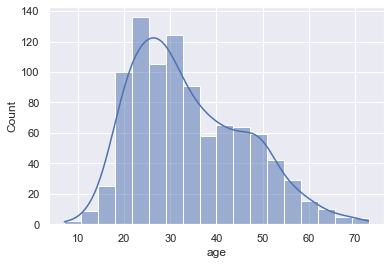

```python
# Age plotted on a histogram

sns.histplot(users['age'], kde=True);
```

**Observation:** Age is positive skewed. More younger people are going for movies compared to older people.

#### Release year

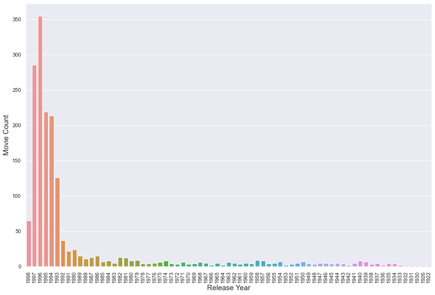

```python
plt.figure(figsize=(15,10))
sns.countplot(x=movies['release date'].str.split('-').str[2].sort_values(ascending=False));
plt.xlabel('Release Year', size=15);
plt.ylabel('Movie Count', size=15);
plt.xticks(rotation=90);
```

**Observation:** Majority of the movies are from 90's

#### Rating

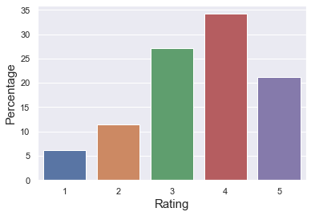

```python
sns.barplot(x='rating', y='rating', data=ratings, estimator=lambda x: len(x) / len(ratings) * 100);
plt.xlabel('Rating', size=15);
plt.ylabel('Percentage', size=15);
```

**Observation:** Ratings are negative skewed with about 35% people rated 4.

#### Gender

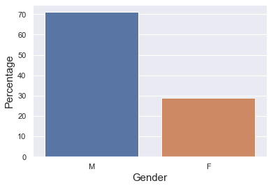

```python
sns.barplot(x='gender', y='user id', data=users, estimator=lambda x: len(x) / len(users) * 100);
plt.xlabel('Gender', size=15);
plt.ylabel('Percentage', size=15);
```

**Observation:** Movie market is shared between male & female in about 70% and 30% respectively.

#### Occupation

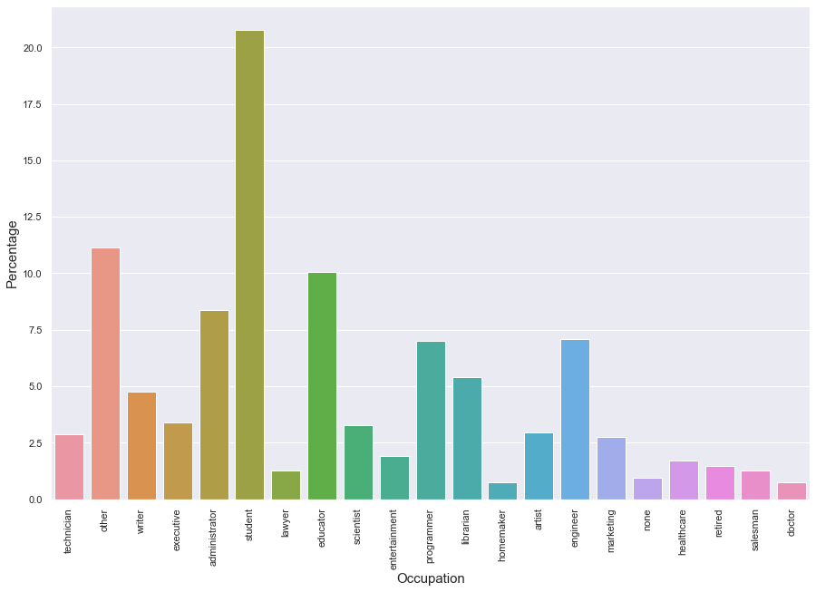

```python
plt.figure(figsize=(15,10))
sns.barplot(x='occupation', y='user id', data=users, estimator=lambda x: len(x) / len(users) * 100);
plt.xlabel('Occupation', size=15);
plt.ylabel('Percentage', size=15);
plt.xticks(rotation=90);
```

**Observation:** Students are the frequent movie goers whereas doctors and homemakers are not that fan of movies or they get minimal chance to watch one.

### 8. Visualize how popularity of genres has changed over the years - 10 marks

Note that you need to use the **percent of number of releases in a year** as a parameter of popularity of a genre

Hint 1: You need to reach to a data frame where the release year is the index and the genre is the column names (one cell shows the number of release in a year in one genre) or vice versa. (Drop unnecessary column if there are any)

Hint 2: Find the total number of movies release in a year(use `sum(axis=1)` store that value in a new column as 'total'). Now divide the value of each genre in that year by total to get percentage number of release in a particular year. `(df.div(df['total'], axis= 0) * 100)`

Once that is achieved, you can either use univariate plots or can use the heatmap to visualise all the changes over the years in one go.

Hint 3: Use groupby on the relevant column and use sum() on the same to find out the number of releases in a year/genre.

```python
movie_popular = movies.copy() # create a copy of movies dataframe
```

```python
movie_popular['year'] = movies['release date'].str.split('-').str[2]  # Extract release year
```

```python
movie_popular.head()  #check if values look good
```

|  | movie id | movie title | release date | unknown | Action | Adventure | Animation | Childrens | Comedy | Crime | ... | Horror | Musical | Mystery | Romance | Sci-Fi | Thriller | War | Western | tot_genre | year |
| --- | --- | --- | --- | --- | --- | --- | --- | --- | --- | --- | --- | --- | --- | --- | --- | --- | --- | --- | --- | --- | --- |
| 0 | 1 | Toy Story | 01-Jan-1995 | 0 | 0 | 0 | 1 | 1 | 1 | 0 | ... | 0 | 0 | 0 | 0 | 0 | 0 | 0 | 0 | 3 | 1995 |
| 1 | 2 | GoldenEye | 01-Jan-1995 | 0 | 1 | 1 | 0 | 0 | 0 | 0 | ... | 0 | 0 | 0 | 0 | 0 | 1 | 0 | 0 | 3 | 1995 |
| 2 | 3 | Four Rooms | 01-Jan-1995 | 0 | 0 | 0 | 0 | 0 | 0 | 0 | ... | 0 | 0 | 0 | 0 | 0 | 1 | 0 | 0 | 1 | 1995 |
| 3 | 4 | Get Shorty | 01-Jan-1995 | 0 | 1 | 0 | 0 | 0 | 1 | 0 | ... | 0 | 0 | 0 | 0 | 0 | 0 | 0 | 0 | 3 | 1995 |
| 4 | 5 | Copycat | 01-Jan-1995 | 0 | 0 | 0 | 0 | 0 | 0 | 1 | ... | 0 | 0 | 0 | 0 | 0 | 1 | 0 | 0 | 3 | 1995 |

5 rows × 24 columns

```python
movie_popular.drop(['movie id','movie title','release date','unknown'], axis=1, inplace=True)
```

```python
movie_popular.columns # check if columns look good
```

```
Index(['Action', 'Adventure', 'Animation', 'Childrens', 'Comedy', 'Crime',
       'Documentary', 'Drama', 'Fantasy', 'Film-Noir', 'Horror', 'Musical',
       'Mystery', 'Romance', 'Sci-Fi', 'Thriller', 'War', 'Western',
       'tot_genre', 'year'],
      dtype='object')
```

```python
movie_popular = movie_popular.groupby('year').sum() # grouping by year and store in same DataFrame
```

```python
movie_popular # validate data
```

| year | Action | Adventure | Animation | Childrens | Comedy | Crime | Documentary | Drama | Fantasy | Film-Noir | Horror | Musical | Mystery | Romance | Sci-Fi | Thriller | War | Western | tot_genre |
| --- | --- | --- | --- | --- | --- | --- | --- | --- | --- | --- | --- | --- | --- | --- | --- | --- | --- | --- | --- |
| 1922 | 0 | 0 | 0 | 0 | 0 | 0 | 0 | 0 | 0 | 0 | 1 | 0 | 0 | 0 | 0 | 0 | 0 | 0 | 1 |
| 1926 | 0 | 0 | 0 | 0 | 0 | 0 | 0 | 1 | 0 | 0 | 0 | 0 | 0 | 0 | 0 | 0 | 0 | 0 | 1 |
| 1930 | 0 | 0 | 0 | 0 | 0 | 0 | 0 | 1 | 0 | 0 | 0 | 0 | 0 | 0 | 0 | 0 | 0 | 0 | 1 |
| 1931 | 0 | 0 | 0 | 0 | 0 | 1 | 0 | 0 | 0 | 1 | 0 | 0 | 0 | 0 | 0 | 1 | 0 | 0 | 3 |
| 1932 | 0 | 0 | 0 | 0 | 0 | 0 | 0 | 0 | 0 | 0 | 0 | 0 | 0 | 1 | 0 | 0 | 1 | 0 | 2 |
| ... | ... | ... | ... | ... | ... | ... | ... | ... | ... | ... | ... | ... | ... | ... | ... | ... | ... | ... | ... |
| 1994 | 30 | 13 | 4 | 15 | 82 | 8 | 9 | 97 | 3 | 0 | 8 | 2 | 2 | 35 | 7 | 25 | 7 | 6 | 353 |
| 1995 | 40 | 22 | 6 | 21 | 63 | 11 | 5 | 89 | 3 | 1 | 14 | 3 | 5 | 37 | 15 | 39 | 5 | 2 | 381 |
| 1996 | 44 | 24 | 9 | 21 | 108 | 21 | 18 | 170 | 6 | 1 | 11 | 9 | 6 | 38 | 15 | 47 | 9 | 2 | 559 |
| 1997 | 46 | 20 | 3 | 22 | 87 | 30 | 6 | 113 | 4 | 2 | 8 | 5 | 18 | 51 | 13 | 54 | 14 | 0 | 496 |
| 1998 | 12 | 3 | 0 | 1 | 13 | 7 | 3 | 33 | 1 | 2 | 4 | 1 | 3 | 11 | 5 | 18 | 0 | 0 | 117 |

71 rows × 19 columns

```python
movie_popular = movie_popular.div(movie_popular['tot_genre'],axis=0)*100  # convert to percentage and store in same dataframe
```

```python
movie_popular # check data
```

| year | Action | Adventure | Animation | Childrens | Comedy | Crime | Documentary | Drama | Fantasy | Film-Noir | Horror | Musical | Mystery | Romance | Sci-Fi | Thriller | War | Western | tot_genre |
| --- | --- | --- | --- | --- | --- | --- | --- | --- | --- | --- | --- | --- | --- | --- | --- | --- | --- | --- | --- |
| 1922 | 0.000000 | 0.000000 | 0.000000 | 0.000000 | 0.000000 | 0.000000 | 0.000000 | 0.000000 | 0.000000 | 0.000000 | 100.000000 | 0.000000 | 0.000000 | 0.000000 | 0.000000 | 0.000000 | 0.000000 | 0.000000 | 100.0 |
| 1926 | 0.000000 | 0.000000 | 0.000000 | 0.000000 | 0.000000 | 0.000000 | 0.000000 | 100.000000 | 0.000000 | 0.000000 | 0.000000 | 0.000000 | 0.000000 | 0.000000 | 0.000000 | 0.000000 | 0.000000 | 0.000000 | 100.0 |
| 1930 | 0.000000 | 0.000000 | 0.000000 | 0.000000 | 0.000000 | 0.000000 | 0.000000 | 100.000000 | 0.000000 | 0.000000 | 0.000000 | 0.000000 | 0.000000 | 0.000000 | 0.000000 | 0.000000 | 0.000000 | 0.000000 | 100.0 |
| 1931 | 0.000000 | 0.000000 | 0.000000 | 0.000000 | 0.000000 | 33.333333 | 0.000000 | 0.000000 | 0.000000 | 33.333333 | 0.000000 | 0.000000 | 0.000000 | 0.000000 | 0.000000 | 33.333333 | 0.000000 | 0.000000 | 100.0 |
| 1932 | 0.000000 | 0.000000 | 0.000000 | 0.000000 | 0.000000 | 0.000000 | 0.000000 | 0.000000 | 0.000000 | 0.000000 | 0.000000 | 0.000000 | 0.000000 | 50.000000 | 0.000000 | 0.000000 | 50.000000 | 0.000000 | 100.0 |
| ... | ... | ... | ... | ... | ... | ... | ... | ... | ... | ... | ... | ... | ... | ... | ... | ... | ... | ... | ... |
| 1994 | 8.498584 | 3.682720 | 1.133144 | 4.249292 | 23.229462 | 2.266289 | 2.549575 | 27.478754 | 0.849858 | 0.000000 | 2.266289 | 0.566572 | 0.566572 | 9.915014 | 1.983003 | 7.082153 | 1.983003 | 1.699717 | 100.0 |
| 1995 | 10.498688 | 5.774278 | 1.574803 | 5.511811 | 16.535433 | 2.887139 | 1.312336 | 23.359580 | 0.787402 | 0.262467 | 3.674541 | 0.787402 | 1.312336 | 9.711286 | 3.937008 | 10.236220 | 1.312336 | 0.524934 | 100.0 |
| 1996 | 7.871199 | 4.293381 | 1.610018 | 3.756708 | 19.320215 | 3.756708 | 3.220036 | 30.411449 | 1.073345 | 0.178891 | 1.967800 | 1.610018 | 1.073345 | 6.797853 | 2.683363 | 8.407871 | 1.610018 | 0.357782 | 100.0 |
| 1997 | 9.274194 | 4.032258 | 0.604839 | 4.435484 | 17.540323 | 6.048387 | 1.209677 | 22.782258 | 0.806452 | 0.403226 | 1.612903 | 1.008065 | 3.629032 | 10.282258 | 2.620968 | 10.887097 | 2.822581 | 0.000000 | 100.0 |
| 1998 | 10.256410 | 2.564103 | 0.000000 | 0.854701 | 11.111111 | 5.982906 | 2.564103 | 28.205128 | 0.854701 | 1.709402 | 3.418803 | 0.854701 | 2.564103 | 9.401709 | 4.273504 | 15.384615 | 0.000000 | 0.000000 | 100.0 |

71 rows × 19 columns

```python
movie_popular.drop('tot_genre', axis=1, inplace=True) # Drop the total column
```

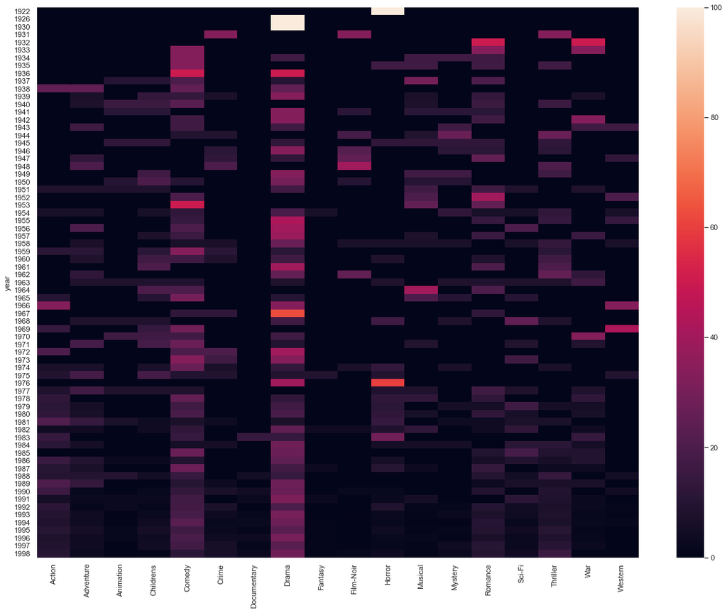

```python
plt.figure(figsize=(20,15))
sns.heatmap(data=movie_popular);
```

**Observation:**

- In initial years only one movie being released in the entire year, that gener got 100% popularity. But being it the only available option not a choice, we can ignore those from popularity standpoint.
- *Drama* and *comedy* seems to be always popular choice over the years.
- *Romance* and *musical* had popularity in old times but in recent years *musical* is not being watched and *romance* became less popular.
- *Thriller* lost the ground from mid **60's** to early **80's**, then again made a come back in recent years.
- *Horror* was pupular between mid **70's** to mid **80's**. </font>

### 9. Find the top 25 movies according to average ratings such that each movie has number of ratings more than 100 - 10 marks

Hints :

1. Find the count of ratings and average ratings for every movie.
2. Slice the movies which have ratings more than 100.
3. Sort values according to average rating such that movie which highest rating is on top.
4. Select top 25 movies.
5. You will have to use the .merge() function to get the movie titles.

Note: This question will need you to research about groupby and apply your findings. You can find more on groupby on https://realpython.com/pandas-groupby/.

```python
# finding rating mean and count grouping by movie title

movies_ratings=pd.merge(ratings,movies, how='inner', on = 'movie id')[['movie title','rating']].groupby('movie title').agg(
    {'rating':['mean','count']})

# converting the columns from two lavel to a single lavel

movies_ratings.columns = ['_'.join(x) for x in movies_ratings.columns.ravel()]
```

```python
movies_ratings  # viewing the data
```

| movie title | rating_mean | rating_count |
| --- | --- | --- |
| 'Til There Was You | 2.333333 | 9 |
| 1-900 | 2.600000 | 5 |
| 101 Dalmatians | 2.908257 | 109 |
| 12 Angry Men | 4.344000 | 125 |
| 187 | 3.024390 | 41 |
| ... | ... | ... |
| Young Guns | 3.207921 | 101 |
| Young Guns II | 2.772727 | 44 |
| Young Poisoner's Handbook, The | 3.341463 | 41 |
| Zeus and Roxanne | 2.166667 | 6 |
| Á köldum klaka (Cold Fever) | 3.000000 | 1 |

1657 rows × 2 columns

```python
# filter with rating count more than 100
# sort values accourding to average on decending order
# select top 25 records

movies_ratings[movies_ratings['rating_count']>100].sort_values('rating_mean',ascending=False).head(25)
```

| movie title | rating_mean | rating_count |
| --- | --- | --- |
| Close Shave, A | 4.491071 | 112 |
| Schindler's List | 4.466443 | 298 |
| Wrong Trousers, The | 4.466102 | 118 |
| Casablanca | 4.456790 | 243 |
| Shawshank Redemption, The | 4.445230 | 283 |
| Rear Window | 4.387560 | 209 |
| Usual Suspects, The | 4.385768 | 267 |
| Star Wars | 4.358491 | 583 |
| 12 Angry Men | 4.344000 | 125 |
| Citizen Kane | 4.292929 | 198 |
| To Kill a Mockingbird | 4.292237 | 219 |
| One Flew Over the Cuckoo's Nest | 4.291667 | 264 |
| Silence of the Lambs, The | 4.289744 | 390 |
| North by Northwest | 4.284916 | 179 |
| Godfather, The | 4.283293 | 413 |
| Secrets & Lies | 4.265432 | 162 |
| Good Will Hunting | 4.262626 | 198 |
| Manchurian Candidate, The | 4.259542 | 131 |
| Dr. Strangelove or: How I Learned to Stop Worrying and Love the Bomb | 4.252577 | 194 |
| Raiders of the Lost Ark | 4.252381 | 420 |
| Vertigo | 4.251397 | 179 |
| Titanic | 4.245714 | 350 |
| Lawrence of Arabia | 4.231214 | 173 |
| Maltese Falcon, The | 4.210145 | 138 |
| Empire Strikes Back, The | 4.204360 | 367 |

### 10. See gender distribution across different genres check for the validity of the below statements - 10 marks

- Men watch more drama than women
- Women watch more Sci-Fi than men
- Men watch more Romance than women

**compare the percentages**

1. Merge all the datasets
2. There is no need to conduct statistical tests around this. Just **compare the percentages** and comment on the validity of the above statements.
3. you might want ot use the .sum(), .div() function here.
4. Use number of ratings to validate the numbers. For example, if out of 4000 ratings received by women, 3000 are for drama, we will assume that 75% of the women watch drama.

```python
# merging three dataframes

merged = pd.merge(pd.merge(ratings,movies,how='inner',on='movie id'),users,how='inner',on='user id')
```

```python
# checking all columns and sample data

merged.head().T
```

|  | 0 | 1 | 2 | 3 | 4 |
| --- | --- | --- | --- | --- | --- |
| user id | 196 | 196 | 196 | 196 | 196 |
| movie id | 242 | 257 | 111 | 25 | 382 |
| rating | 3 | 2 | 4 | 4 | 4 |
| timestamp | 881250949 | 881251577 | 881251793 | 881251955 | 881251843 |
| movie title | Kolya | Men in Black | Truth About Cats & Dogs, The | Birdcage, The | Adventures of Priscilla, Queen of the Desert, ... |
| release date | 24-Jan-1997 | 04-Jul-1997 | 26-Apr-1996 | 08-Mar-1996 | 01-Jan-1994 |
| unknown | 0 | 0 | 0 | 0 | 0 |
| Action | 0 | 1 | 0 | 0 | 0 |
| Adventure | 0 | 1 | 0 | 0 | 0 |
| Animation | 0 | 0 | 0 | 0 | 0 |
| Childrens | 0 | 0 | 0 | 0 | 0 |
| Comedy | 1 | 1 | 1 | 1 | 1 |
| Crime | 0 | 0 | 0 | 0 | 0 |
| Documentary | 0 | 0 | 0 | 0 | 0 |
| Drama | 0 | 0 | 0 | 0 | 1 |
| Fantasy | 0 | 0 | 0 | 0 | 0 |
| Film-Noir | 0 | 0 | 0 | 0 | 0 |
| Horror | 0 | 0 | 0 | 0 | 0 |
| Musical | 0 | 0 | 0 | 0 | 0 |
| Mystery | 0 | 0 | 0 | 0 | 0 |
| Romance | 0 | 0 | 1 | 0 | 0 |
| Sci-Fi | 0 | 1 | 0 | 0 | 0 |
| Thriller | 0 | 0 | 0 | 0 | 0 |
| War | 0 | 0 | 0 | 0 | 0 |
| Western | 0 | 0 | 0 | 0 | 0 |
| tot_genre | 1 | 4 | 2 | 1 | 2 |
| age | 49 | 49 | 49 | 49 | 49 |
| gender | M | M | M | M | M |
| occupation | writer | writer | writer | writer | writer |
| zip code | 55105 | 55105 | 55105 | 55105 | 55105 |

```python
# drop all unwanted columns

merged.drop(['user id','movie id','rating','timestamp','movie title','release date','unknown','age','occupation',
             'zip code'],
             axis=1,inplace=True)
```

```python
# checking all columns and sample data

merged.head().T
```

|  | 0 | 1 | 2 | 3 | 4 |
| --- | --- | --- | --- | --- | --- |
| Action | 0 | 1 | 0 | 0 | 0 |
| Adventure | 0 | 1 | 0 | 0 | 0 |
| Animation | 0 | 0 | 0 | 0 | 0 |
| Childrens | 0 | 0 | 0 | 0 | 0 |
| Comedy | 1 | 1 | 1 | 1 | 1 |
| Crime | 0 | 0 | 0 | 0 | 0 |
| Documentary | 0 | 0 | 0 | 0 | 0 |
| Drama | 0 | 0 | 0 | 0 | 1 |
| Fantasy | 0 | 0 | 0 | 0 | 0 |
| Film-Noir | 0 | 0 | 0 | 0 | 0 |
| Horror | 0 | 0 | 0 | 0 | 0 |
| Musical | 0 | 0 | 0 | 0 | 0 |
| Mystery | 0 | 0 | 0 | 0 | 0 |
| Romance | 0 | 0 | 1 | 0 | 0 |
| Sci-Fi | 0 | 1 | 0 | 0 | 0 |
| Thriller | 0 | 0 | 0 | 0 | 0 |
| War | 0 | 0 | 0 | 0 | 0 |
| Western | 0 | 0 | 0 | 0 | 0 |
| tot_genre | 1 | 4 | 2 | 1 | 2 |
| gender | M | M | M | M | M |

```python
# grouping by gender to see total ratings per genre also overall total

merged = merged.groupby('gender').sum()
```

```python
# validatin data

merged.T
```

| gender | F | M |
| --- | --- | --- |
| Action | 5442 | 20147 |
| Adventure | 3141 | 10612 |
| Animation | 995 | 2610 |
| Childrens | 2232 | 4950 |
| Comedy | 8068 | 21764 |
| Crime | 1794 | 6261 |
| Documentary | 187 | 571 |
| Drama | 11008 | 28887 |
| Fantasy | 363 | 989 |
| Film-Noir | 385 | 1348 |
| Horror | 1197 | 4120 |
| Musical | 1442 | 3512 |
| Mystery | 1314 | 3931 |
| Romance | 5858 | 13603 |
| Sci-Fi | 2629 | 10101 |
| Thriller | 5086 | 16786 |
| War | 2189 | 7209 |
| Western | 371 | 1483 |
| tot_genre | 53701 | 158884 |

```python
# calculate percentage

merged = merged.div(merged['tot_genre'],axis=0)*100
```

```python
# validatin data

merged.T
```

| gender | F | M |
| --- | --- | --- |
| Action | 10.133889 | 12.680320 |
| Adventure | 5.849053 | 6.679087 |
| Animation | 1.852852 | 1.642708 |
| Childrens | 4.156347 | 3.115480 |
| Comedy | 15.023929 | 13.698044 |
| Crime | 3.340720 | 3.940611 |
| Documentary | 0.348224 | 0.359382 |
| Drama | 20.498687 | 18.181189 |
| Fantasy | 0.675965 | 0.622467 |
| Film-Noir | 0.716933 | 0.848418 |
| Horror | 2.229009 | 2.593087 |
| Musical | 2.685239 | 2.210418 |
| Mystery | 2.446882 | 2.474132 |
| Romance | 10.908549 | 8.561592 |
| Sci-Fi | 4.895626 | 6.357468 |
| Thriller | 9.470960 | 10.564940 |
| War | 4.076274 | 4.537272 |
| Western | 0.690862 | 0.933385 |
| tot_genre | 100.000000 | 100.000000 |

```python
# drop total rating

merged.drop('tot_genre',axis=1, inplace=True)
```

```python
# Transpose the data

merged=merged.transpose()
```

```python
# check data

merged
```

| gender | F | M |
| --- | --- | --- |
| Action | 10.133889 | 12.680320 |
| Adventure | 5.849053 | 6.679087 |
| Animation | 1.852852 | 1.642708 |
| Childrens | 4.156347 | 3.115480 |
| Comedy | 15.023929 | 13.698044 |
| Crime | 3.340720 | 3.940611 |
| Documentary | 0.348224 | 0.359382 |
| Drama | 20.498687 | 18.181189 |
| Fantasy | 0.675965 | 0.622467 |
| Film-Noir | 0.716933 | 0.848418 |
| Horror | 2.229009 | 2.593087 |
| Musical | 2.685239 | 2.210418 |
| Mystery | 2.446882 | 2.474132 |
| Romance | 10.908549 | 8.561592 |
| Sci-Fi | 4.895626 | 6.357468 |
| Thriller | 9.470960 | 10.564940 |
| War | 4.076274 | 4.537272 |
| Western | 0.690862 | 0.933385 |

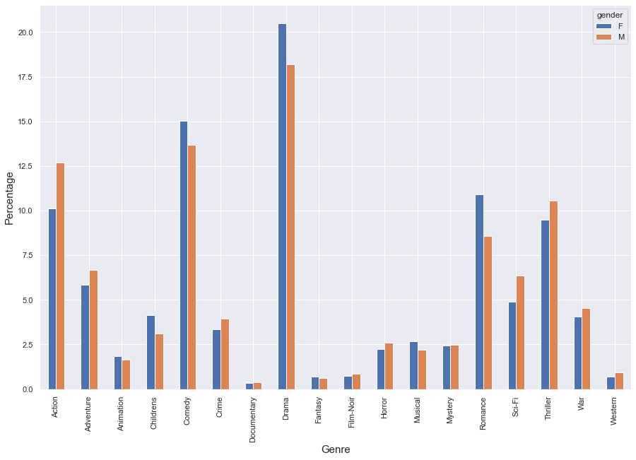

```python
merged.plot(kind='bar',figsize=(15,10));
plt.xlabel('Genre', size=15);
plt.ylabel('Percentage', size=15);
```

**Statement validations:**

- **Men watch more drama than women**
  - *False: About 20.5% women watch drama compared to 18.2% men.*
- **Women watch more Sci-Fi than men**
  - *False: About 4.9% women watch Sci-Fi compared to 6.4% men.*
- **Men watch more Romance than women**
  - *False: About 10.9% women watch Romance compared to 8.6% men.*